# Determinants of the Interest in Electric Vehicles

Dec. 4th, 2015

## Introduction

- Why electric vehicles?
  - climate change, GHG emissions from cars
  - Government promoting low-emission vehicles
- Problem: low adoption

## Purpose of Research

- Identify the characteristics of potential EV buyers
- Identify the factors encouraging/putting off buying EVs

## Data Source

- ["Opinions and Lifestyle Survey, Electric Vehicles Module, February 2014 and February 2015"](https://discover.ukdataservice.ac.uk/Catalogue/?sn=7571&type=Data%20catalogue)
- Source: Social Survey Division of the Office for National Statistics, the U.K.
- Survey year: 2014 and 2015.
- Sample size: 1,710

## List of Variables

- Dependent variables
  - Interests in EVs
- Independent variables
  - Age, Sex, Income, Education
  - Drivers licence, Number of Cars
  - Household size, Children
  - Region
- Other variables
  - Factors encouraging/putting off buying EVs
  - Cost-related factors encouraging/putting off buying EVs

## Methodology

### Logistic Regression

\[\ln{\frac{p}{1-p}}=\beta_{0} + \beta_{1} x_{1i} + \beta_{2} x_{2i} + \dots + \beta_{k} x_{ki}\]

\[p=\frac{1} {1 + exp\{-(\beta_{0} + \beta_{1} x_{1i} + \beta_{2} x_{2i} + \dots + \beta_{k} x_{ki})\}}\]

\(p\): probability of being interested in buying an EV

## Descriptive Analysis

### Dependent Variables: Interest in EVs

- National average: 18.48%

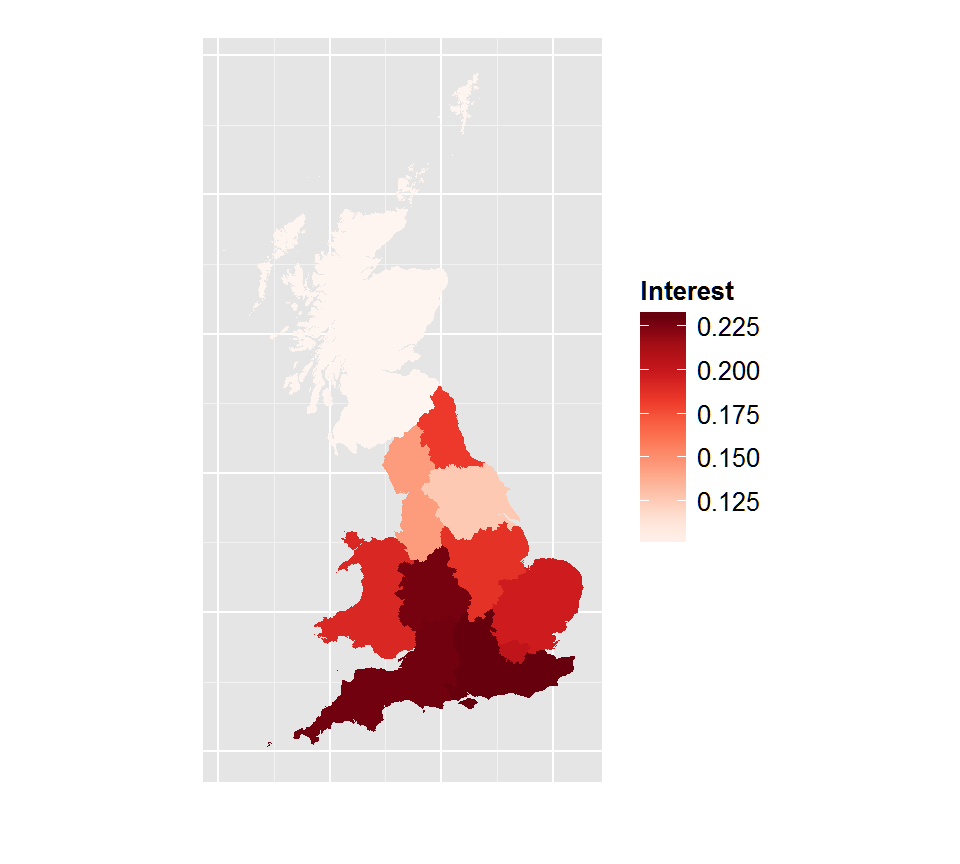

## Descriptive Analysis

### Independent Variables

- Average Age: 52.03
- 46.84% Male, 53.16% Female
- 24.39% college graduates
- 76.55% have drivers licence
- Average number of cars: 1.14
- Income level:

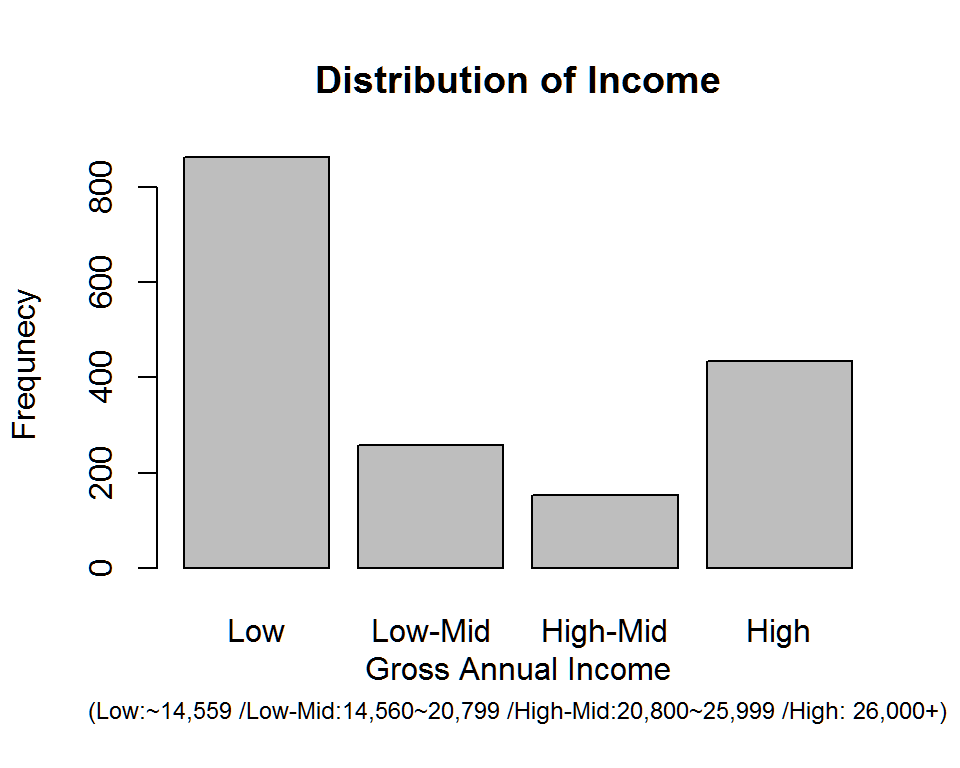

## Logistic Regression

### Interest in EVs

\[\ln{(\frac{p} {1-p})}=\underset{(.29^{***})}{-2.56}-\underset{(.004^{*})}{.01\textbf{Age}}+\underset{(.14^{***})}{.47\textbf{Male}}\underset{(.21)}{-.10Lowmid}+\underset{(.24)}{.03Highmid}\]

\[+\underset{(.17^*)}{.29\textbf{High}}+\underset{(.15^{***})}{.65\textbf{College}}+\underset{(.24^{***})}{.91\textbf{license}}+\underset{(.09^{**})}{.18\textbf{NumCar}}-\underset{(.29^{**})}{.70\textbf{Scotland}}\]

*Note:* \(^{*}p<0.1\); \(^{**}p<0.05\); \(^{***}p<0.01\)

\(R^2=0.12\)

## Predicted Probabilities

### Gender & Age

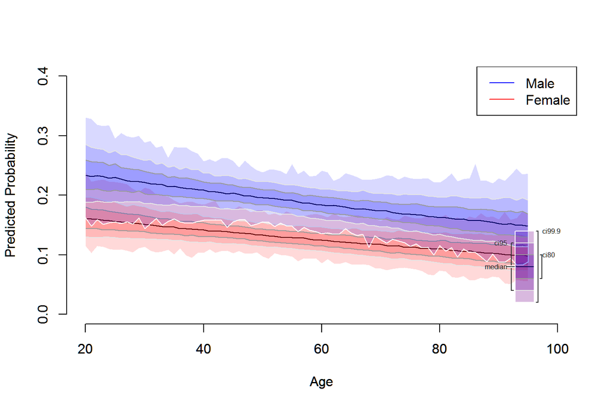

## Predicted Probabilities

### Degree & Licence

Probability by Education Level & Sex (%)

| Education Level | Male | Female |
| --- | --- | --- |
| At least have a college degree | 30.02 | 21.22 |
| Do not have a college degree | 18.35 | 12.37 |

Probabilities by Driver's License Status & Sex (%)

| License Status | Male | Female |
| --- | --- | --- |
| Have driver's license | 30.02 | 21.22 |
| Do not have driver's license | 14.74 | 9.8 |

## Factors Encouraging/Putting Off Buying EVs

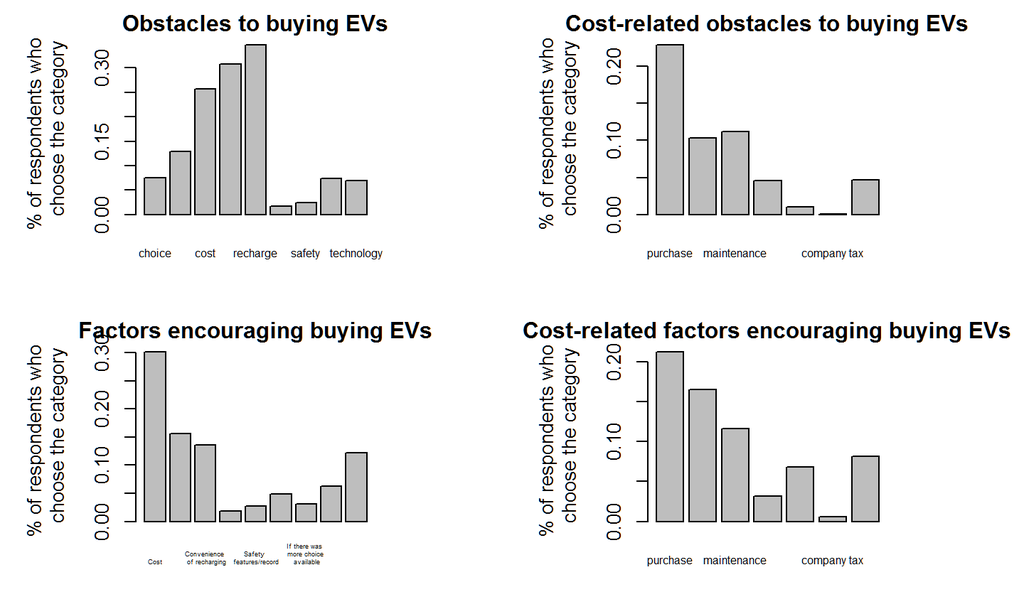

## Recommendations (1)

- Information campaign
  - General information campaign (on energy costs and environmental responsibility)
  - Information campaigns targeting on low-ineterest groups
- Investment in R&D
  - Increasing the battery capacity of EVs
  - Improving the efficiency of recharging facilities
- Putting recharing facilities in place
  - Long-term plan on it

## Recommendations (2)

- Financial incentives
  - Policies that immediately reduce purchase price
- Differentiated marketing strategies